# Predicting Default Rates

Francisco J. Buenrostro

2024-07-15

## Introduction

In this example, we will explore a data set that contains information on default payments, demographic factors, credit data, history of payment, and bill statements of credit card clients in Taiwan from April 2005 to September 2005.

This data set was obtained from the University of California, Irvine archives.

Source: https://archive.ics.uci.edu/ml/datasets/default+of+credit+card+clients

The Default of Credit Card Clients data set will allow us to practice key data skills. The first, is **data acquisition**, by obtaining and importing our data into RStudio. The second, is **data preparation**, by cleaning and manipulating the variables within the data set to prepare for the analytics portion of the project. The third, is **data analytics**, using statistics, logistical regression, and predictive models to uncover insights into our dependent and independent variables. The last data skill we will use is **data visualization**, by creating charts and graphs throughout the project to better portray what is happening within the data.

## Project Goals

### Goal 1:

Employ exploratory data analytics techniques on the data set to uncover new insights.

### Goal 2:

Run a logistical regression to predict the probability of a new credit card client defaulting on their next month’s credit card payment.

### Goal 3:

Run a “PCA” Principal Component Analysis on the data set and observe how the first 5 principal components load all of the variables.

## Variable Name + Description

There are 25 variables.

**ID:** ID of each client

**LIMIT_BAL:** Amount of given credit in NT dollars (includes individual and family/supplementary credit

**SEX:** Gender (1=male, 2=female)

**EDUCATION:** (1=graduate school, 2=university, 3=high school, 4=others, 5=unknown, 6=unknown)

**MARRIAGE:** Marital status (1=married, 2=single, 3=others) AGE: Age in years

**PAY_0:** Repayment status in September, 2005 (-2=pay fully for the balance, -1=pay at least for the minimum requirement, 0=payment delay for one month, 1=payment delay for two months, … 7=payment delay for eight months, 8=payment delay for nine months and above)

**PAY_2:** Repayment status in August, 2005 (scale same as above)

**PAY_3:** Repayment status in July, 2005 (scale same as above)

**PAY_4:** Repayment status in June, 2005 (scale same as above)

**PAY_5:** Repayment status in May, 2005 (scale same as above)

**PAY_6:** Repayment status in April, 2005 (scale same as above)

**BILL_AMT1:** Amount of bill statement in September, 2005 (NT dollar)

**BILL_AMT2:** Amount of bill statement in August, 2005 (NT dollar)

**BILL_AMT3:** Amount of bill statement in July, 2005 (NT dollar)

**BILL_AMT4:** Amount of bill statement in June, 2005 (NT dollar)

**BILL_AMT5:** Amount of bill statement in May, 2005 (NT dollar)

**BILL_AMT6:** Amount of bill statement in April, 2005 (NT dollar)

**PAY_AMT1:** Amount of previous payment in September, 2005 (NT dollar)

**PAY_AMT2:** Amount of previous payment in August, 2005 (NT dollar)

**PAY_AMT3:** Amount of previous payment in July, 2005 (NT dollar)

**PAY_AMT4:** Amount of previous payment in June, 2005 (NT dollar)

**PAY_AMT5:** Amount of previous payment in May, 2005 (NT dollar)

**PAY_AMT6:** Amount of previous payment in April, 2005 (NT dollar)

**default.payment.next.month:** Default payment (1=yes, 0=no)

## Exploring the Data

First, Let us load the data into R and take an initial look at what we are dealing with. the str() function will allow us to compactly display the internal structure of our data set “credit1”. the summary() function will allow us to view a statistical summary of each of the variables we are dealing with.

```r
credit1 = read.csv("creditcard.csv")
str(credit1)
```

```
## 'data.frame':    30000 obs. of  25 variables:
##  $ ID                        : int  1 2 3 4 5 6 7 8 9 10 ...
##  $ LIMIT_BAL                 : num  20000 120000 90000 50000 50000 50000 500000 100000 140000 20000 ...
##  $ SEX                       : int  2 2 2 2 1 1 1 2 2 1 ...
##  $ EDUCATION                 : int  2 2 2 2 2 1 1 2 3 3 ...
##  $ MARRIAGE                  : int  1 2 2 1 1 2 2 2 1 2 ...
##  $ AGE                       : int  24 26 34 37 57 37 29 23 28 35 ...
##  $ PAY_0                     : int  2 -1 0 0 -1 0 0 0 0 -2 ...
##  $ PAY_2                     : int  2 2 0 0 0 0 0 -1 0 -2 ...
##  $ PAY_3                     : int  -1 0 0 0 -1 0 0 -1 2 -2 ...
##  $ PAY_4                     : int  -1 0 0 0 0 0 0 0 0 -2 ...
##  $ PAY_5                     : int  -2 0 0 0 0 0 0 0 0 -1 ...
##  $ PAY_6                     : int  -2 2 0 0 0 0 0 -1 0 -1 ...
##  $ BILL_AMT1                 : num  3913 2682 29239 46990 8617 ...
##  $ BILL_AMT2                 : num  3102 1725 14027 48233 5670 ...
##  $ BILL_AMT3                 : num  689 2682 13559 49291 35835 ...
##  $ BILL_AMT4                 : num  0 3272 14331 28314 20940 ...
##  $ BILL_AMT5                 : num  0 3455 14948 28959 19146 ...
##  $ BILL_AMT6                 : num  0 3261 15549 29547 19131 ...
##  $ PAY_AMT1                  : num  0 0 1518 2000 2000 ...
##  $ PAY_AMT2                  : num  689 1000 1500 2019 36681 ...
##  $ PAY_AMT3                  : num  0 1000 1000 1200 10000 657 38000 0 432 0 ...
##  $ PAY_AMT4                  : num  0 1000 1000 1100 9000 ...
##  $ PAY_AMT5                  : num  0 0 1000 1069 689 ...
##  $ PAY_AMT6                  : num  0 2000 5000 1000 679 ...
##  $ default.payment.next.month: int  1 1 0 0 0 0 0 0 0 0 ...
```

```r
summary(credit1)
```

```
##        ID          LIMIT_BAL            SEX          EDUCATION
##  Min.   :    1   Min.   :  10000   Min.   :1.000   Min.   :0.000
##  1st Qu.: 7501   1st Qu.:  50000   1st Qu.:1.000   1st Qu.:1.000
##  Median :15000   Median : 140000   Median :2.000   Median :2.000
##  Mean   :15000   Mean   : 167484   Mean   :1.604   Mean   :1.853
##  3rd Qu.:22500   3rd Qu.: 240000   3rd Qu.:2.000   3rd Qu.:2.000
##  Max.   :30000   Max.   :1000000   Max.   :2.000   Max.   :6.000
##     MARRIAGE          AGE            PAY_0             PAY_2
##  Min.   :0.000   Min.   :21.00   Min.   :-2.0000   Min.   :-2.0000
##  1st Qu.:1.000   1st Qu.:28.00   1st Qu.:-1.0000   1st Qu.:-1.0000
##  Median :2.000   Median :34.00   Median : 0.0000   Median : 0.0000
##  Mean   :1.552   Mean   :35.49   Mean   :-0.0167   Mean   :-0.1338
##  3rd Qu.:2.000   3rd Qu.:41.00   3rd Qu.: 0.0000   3rd Qu.: 0.0000
##  Max.   :3.000   Max.   :79.00   Max.   : 8.0000   Max.   : 8.0000
##      PAY_3             PAY_4             PAY_5             PAY_6
##  Min.   :-2.0000   Min.   :-2.0000   Min.   :-2.0000   Min.   :-2.0000
##  1st Qu.:-1.0000   1st Qu.:-1.0000   1st Qu.:-1.0000   1st Qu.:-1.0000
##  Median : 0.0000   Median : 0.0000   Median : 0.0000   Median : 0.0000
##  Mean   :-0.1662   Mean   :-0.2207   Mean   :-0.2662   Mean   :-0.2911
##  3rd Qu.: 0.0000   3rd Qu.: 0.0000   3rd Qu.: 0.0000   3rd Qu.: 0.0000
##  Max.   : 8.0000   Max.   : 8.0000   Max.   : 8.0000   Max.   : 8.0000
##    BILL_AMT1         BILL_AMT2        BILL_AMT3         BILL_AMT4
##  Min.   :-165580   Min.   :-69777   Min.   :-157264   Min.   :-170000
##  1st Qu.:   3559   1st Qu.:  2985   1st Qu.:   2666   1st Qu.:   2327
##  Median :  22382   Median : 21200   Median :  20089   Median :  19052
##  Mean   :  51223   Mean   : 49179   Mean   :  47013   Mean   :  43263
##  3rd Qu.:  67091   3rd Qu.: 64006   3rd Qu.:  60165   3rd Qu.:  54506
##  Max.   : 964511   Max.   :983931   Max.   :1664089   Max.   : 891586
##    BILL_AMT5        BILL_AMT6          PAY_AMT1         PAY_AMT2
##  Min.   :-81334   Min.   :-339603   Min.   :     0   Min.   :      0
##  1st Qu.:  1763   1st Qu.:   1256   1st Qu.:  1000   1st Qu.:    833
##  Median : 18105   Median :  17071   Median :  2100   Median :   2009
##  Mean   : 40311   Mean   :  38872   Mean   :  5664   Mean   :   5921
##  3rd Qu.: 50191   3rd Qu.:  49198   3rd Qu.:  5006   3rd Qu.:   5000
##  Max.   :927171   Max.   : 961664   Max.   :873552   Max.   :1684259
##     PAY_AMT3         PAY_AMT4         PAY_AMT5           PAY_AMT6
##  Min.   :     0   Min.   :     0   Min.   :     0.0   Min.   :     0.0
##  1st Qu.:   390   1st Qu.:   296   1st Qu.:   252.5   1st Qu.:   117.8
##  Median :  1800   Median :  1500   Median :  1500.0   Median :  1500.0
##  Mean   :  5226   Mean   :  4826   Mean   :  4799.4   Mean   :  5215.5
##  3rd Qu.:  4505   3rd Qu.:  4013   3rd Qu.:  4031.5   3rd Qu.:  4000.0
##  Max.   :896040   Max.   :621000   Max.   :426529.0   Max.   :528666.0
##  default.payment.next.month
##  Min.   :0.0000
##  1st Qu.:0.0000
##  Median :0.0000
##  Mean   :0.2212
##  3rd Qu.:0.0000
##  Max.   :1.0000
```

### Missing Values & Unwanted Variables

The next step is to find out if we have any missing value, or if we will need to preform other types of data management.

```r
library(dplyr)
missing = credit1 %>% summarise_all(funs(sum(is.na(.))/n()))
missing
```

```
##   ID LIMIT_BAL SEX EDUCATION MARRIAGE AGE PAY_0 PAY_2 PAY_3 PAY_4 PAY_5 PAY_6
## 1  0         0   0         0        0   0     0     0     0     0     0     0
##   BILL_AMT1 BILL_AMT2 BILL_AMT3 BILL_AMT4 BILL_AMT5 BILL_AMT6 PAY_AMT1 PAY_AMT2
## 1         0         0         0         0         0         0        0        0
##   PAY_AMT3 PAY_AMT4 PAY_AMT5 PAY_AMT6 default.payment.next.month
## 1        0        0        0        0                          0
```

```r
# Lets remove the ID variable it is not needed
credit=credit1[,-1]
```

### Data Visualizations

Now lets create some data visualizations to learn more about the data. The first visualization will look at the percentage of clients who have not defaulted vs the those who have defaulted.

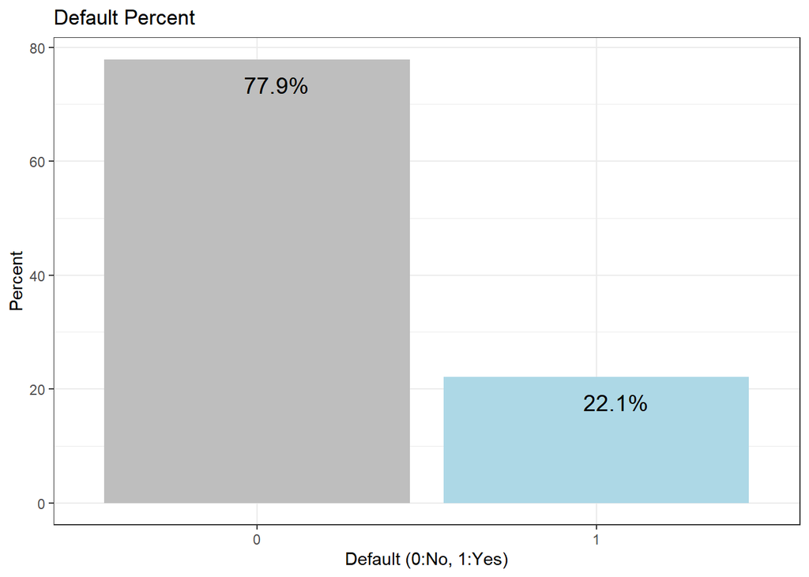

```r
library(ggplot2)
credit %>%
  group_by(default.payment.next.month) %>%
  summarise(Count = n())%>%
  mutate(percent = prop.table(Count)*100)%>%
  ggplot(aes(reorder(default.payment.next.month, -percent), percent), fill = default.payment.next.month)+
  geom_col(fill = c("grey", "light blue"))+
  geom_text(aes(label = sprintf("%.1f%%", percent)), hjust = 0.2, vjust = 2, size = 5)+
  theme_bw()+
  xlab("Default (0:No, 1:Yes)") + ylab("Percent") + ggtitle("Default Percent")
```

### Comment

We see that 22.1% of clients have defaulted on their monthly payment and 77.9% of clients have not.

### Visuals Continued

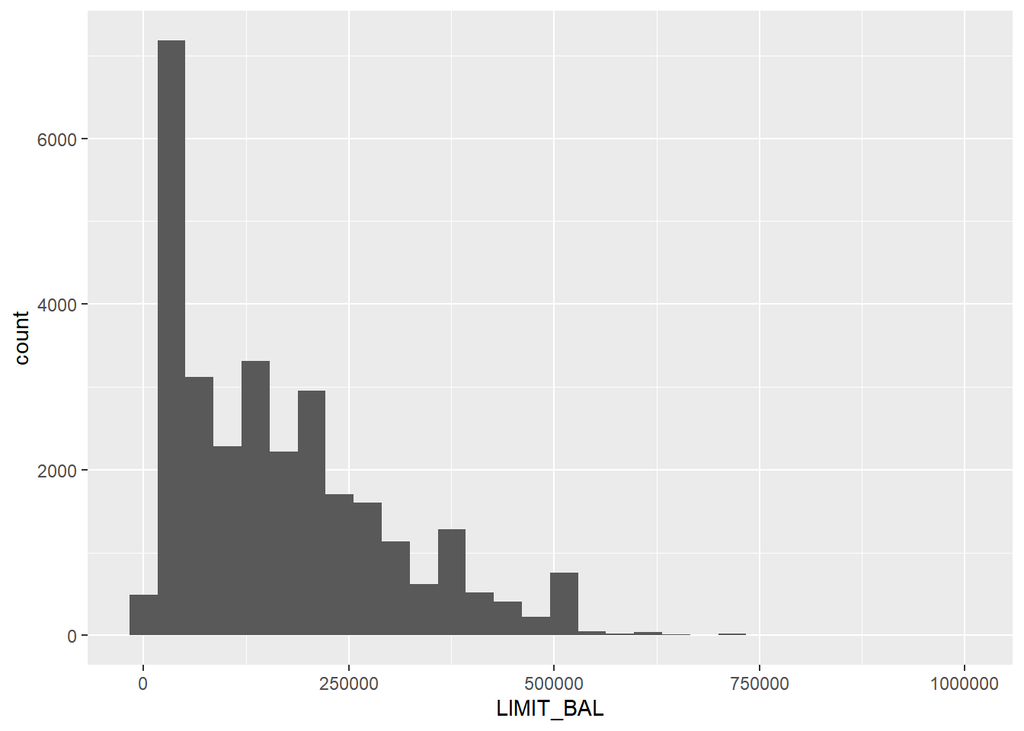

```r
library(ggplot2)
ggplot(credit, aes(x = LIMIT_BAL)) + geom_histogram()
```

### LIMIT_BAL Histogram Comment

If we look at the Histogram using our LIMIT_BAL variable it shows us the number of clients with a given credit balance in Taiwan Dollars. We can see that there is a large amount of clients with lower credit balances and a lower number of clients with higher credit amounts.

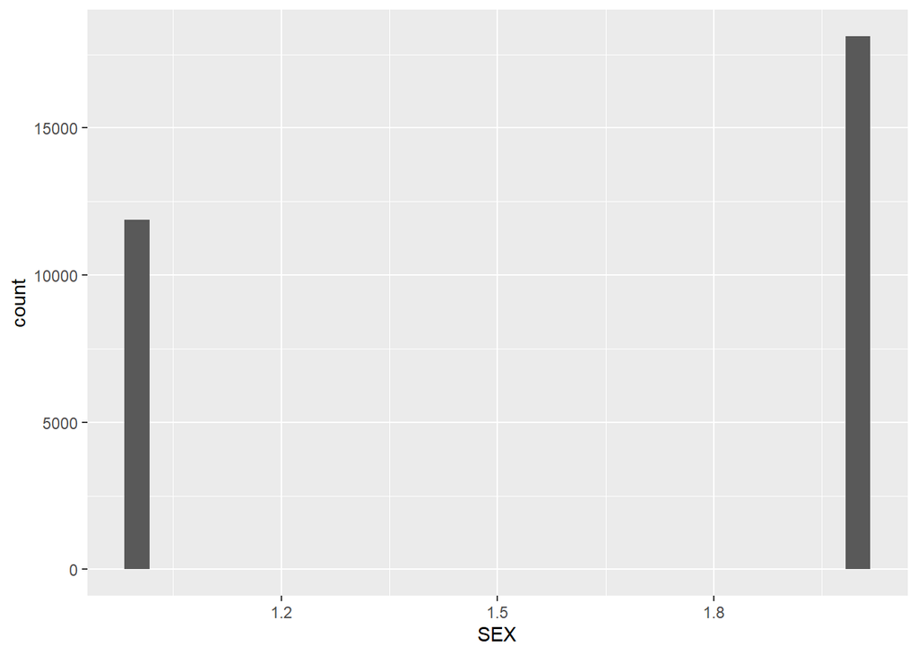

```r
library(ggplot2)
ggplot(credit, aes(x = SEX)) + geom_histogram()
```

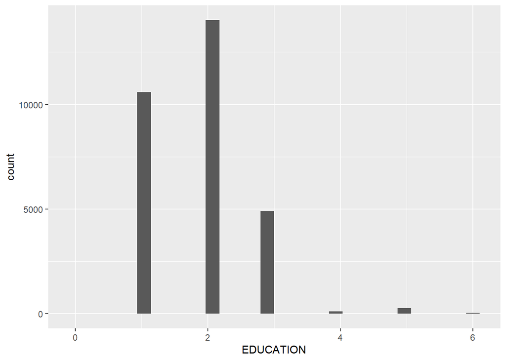

```r
ggplot(credit, aes(x = EDUCATION)) + geom_histogram()
```

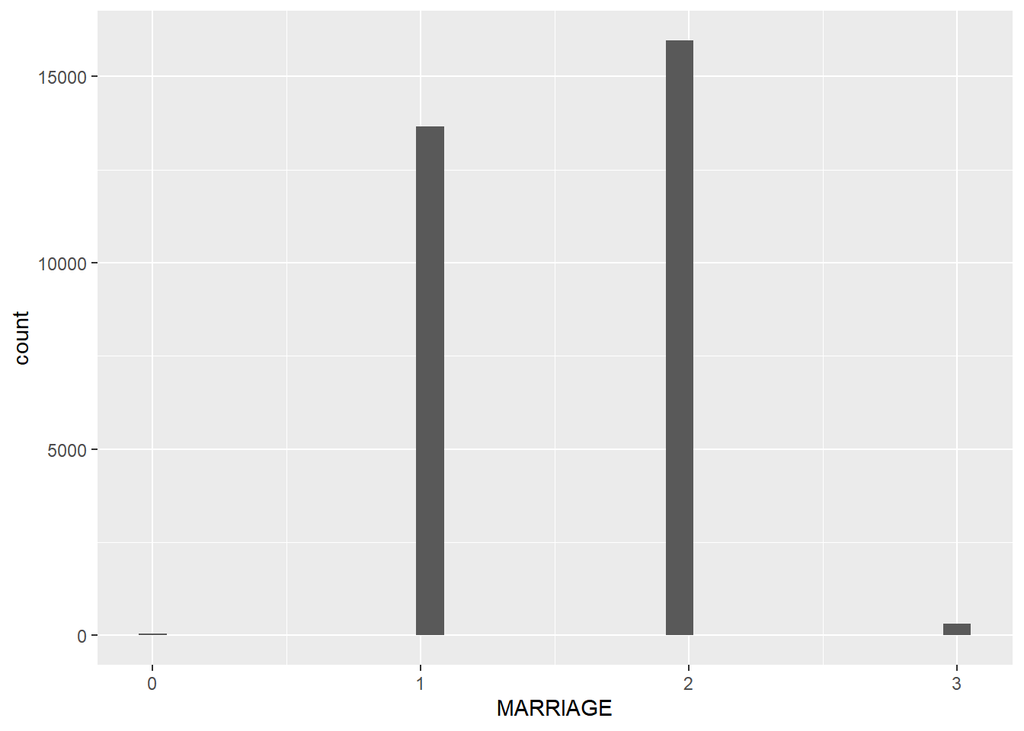

```r
ggplot(credit, aes(x = MARRIAGE)) + geom_histogram()
```

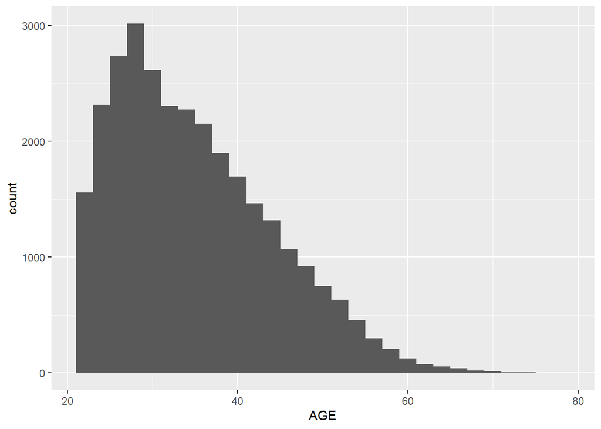

```r
ggplot(credit, aes(x = AGE)) + geom_histogram()
```

### AGE Histogram Comment

If we look at the Histogram using our AGE variable it shows us the number of credit card clients by age. We can see that the majority of clients are younger than 40 years of age.

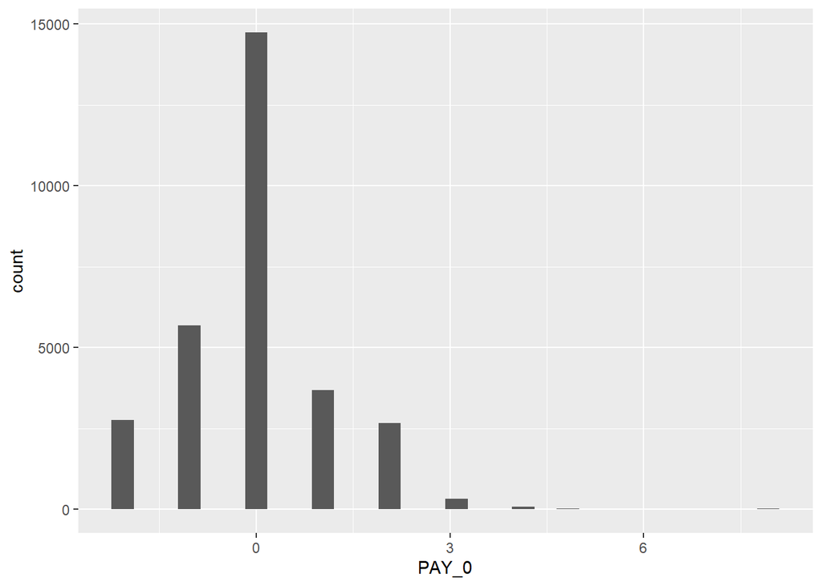

```r
library(ggplot2)
ggplot(credit, aes(x = PAY_0)) + geom_histogram()
```

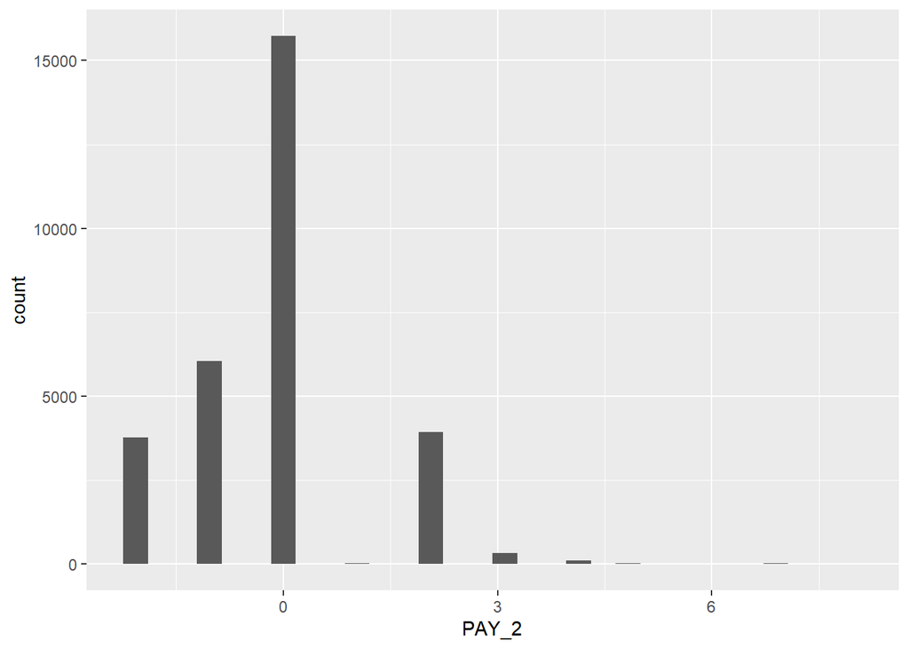

```r
ggplot(credit, aes(x = PAY_2)) + geom_histogram()
```

```r
table(credit$PAY_0)
```

```
##
##    -2    -1     0     1     2     3     4     5     6     7     8
##  2759  5686 14737  3688  2667   322    76    26    11     9    19
```

### Data Management

Here we will preform some data management by combining variables that have a low number of observations with other variables that have low numbers of observations. We will also create some visuals for the new combined variables as well as turn some numeric variables into factors. This is so that we are able to run our logistical regression in the next steps.

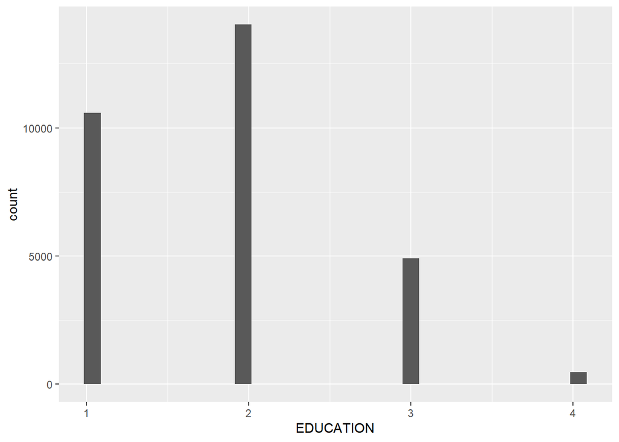

```r
# There are some catergories with very few observations. Let's group them together.
credit$EDUCATION[credit$EDUCATION == 0] = 4
credit$EDUCATION[credit$EDUCATION == 5] = 4
credit$EDUCATION[credit$EDUCATION == 6] = 4
credit$MARRIAGE[credit$MARRIAGE == 0] = 3

ggplot(credit, aes(x = EDUCATION)) + geom_histogram()
```

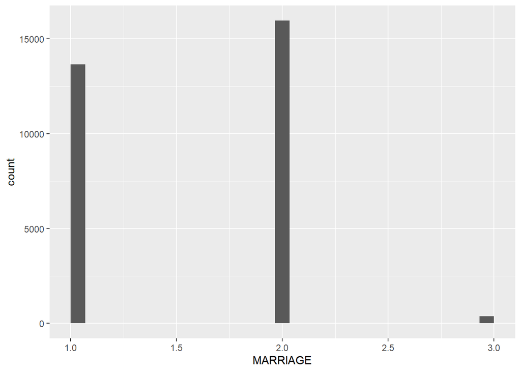

```r
ggplot(credit, aes(x = MARRIAGE)) + geom_histogram()
```

```r
# Make some numeric variables into factors
credit$default.payment.next.month=as.factor(credit$default.payment.next.month)
credit$SEX=as.factor(credit$SEX)
credit$EDUCATION=as.factor(credit$EDUCATION)
credit$MARRIAGE=as.factor(credit$MARRIAGE)
```

### Exploratory Data Analysis

Let us explore our data a little bit more. In this section we will run some simple EDA “Exploratory Data Analysis” by using ggplot to create some bar charts, box plot, and violin charts. This will help us better understand our data.

### Bar Chart

In the bar charts there are two components the first being the variable that we are observing which is on the X - axis, and the second is if the client defaulted on their monthly payment where the salmon color means no, and the blue means yes.

If we take a look at the education bar chart where, 1 = graduate school, 2 = university, 3 = high school, and 4 = other. We can see that the majority of the credit card clients have a university degree or higher. We can also see the split between clients who did not default on their payment an clients who did default on their payment relative to the category the client falls under.

### Violin and Box Chart

If we look at the violin and box charts. The first thing we notice is that we have separated the clients who have defaulted on their credit card payment from those who did not. We did this to compare the two groups to each other.

In the violin and box charts, like the bar charts, are made up of multiple components. This time our variable we are observing is on the Y - axis. The first part of our visual insights is the violin, or blob looking portion of the chart. This part of the chart allows us to see the density of observations as we move up from 0. The wider the blob the greater the number of observations, the narrower the blob the lesser the number of observations. The second part, is the box plot which allows us to see the median, upper quartile, lower quartile, and both upper and lower extremes. The last part is if the client defaulted on their monthly payment where the salmon color means no, and the blue means yes.

Lets take a look at the characteristics of the clients who did not default on their payment compared to those of the clients who did using our limit_bal variable. The first thing to make note of is that the group that defaulted has a wider base, letting us know that there was a large amount of clients who defaulted with lower credit limits available to them. The second thing we notice is that the group that did not default has more clients with larger credit limits and an outlier with a really high credit limit compared to the default group.

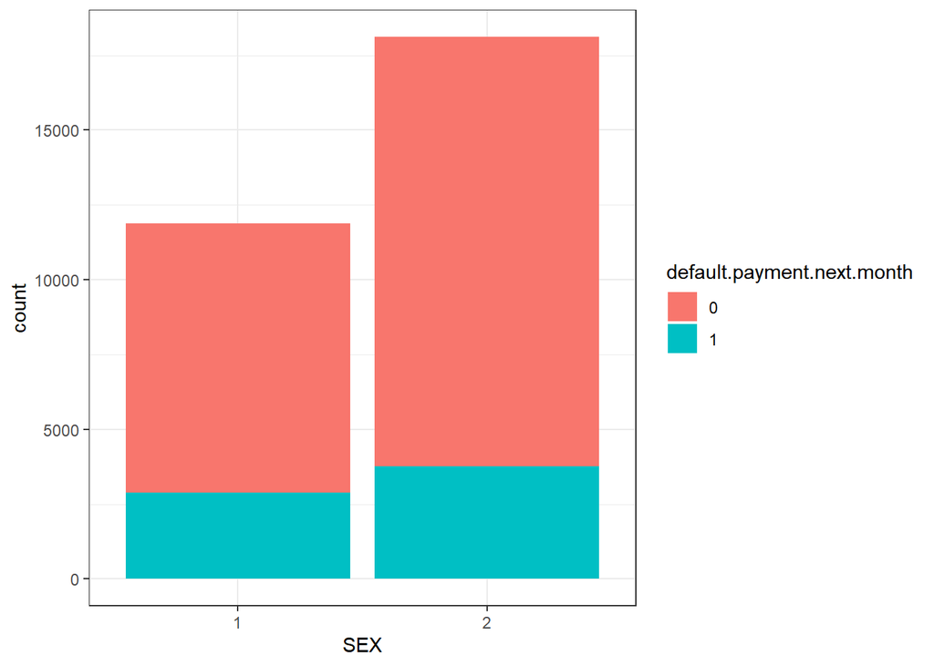

```r
# Some EDA
# Default against categorical variables
ggplot(credit, aes(x=SEX,fill=default.payment.next.month))+ geom_bar()+ theme_bw()
```

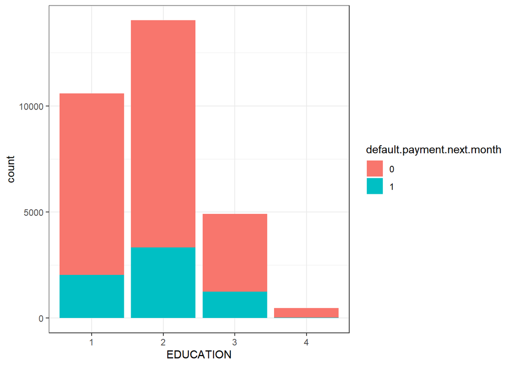

```r
ggplot(credit, aes(x=EDUCATION,fill=default.payment.next.month))+ geom_bar()+theme_bw()
```

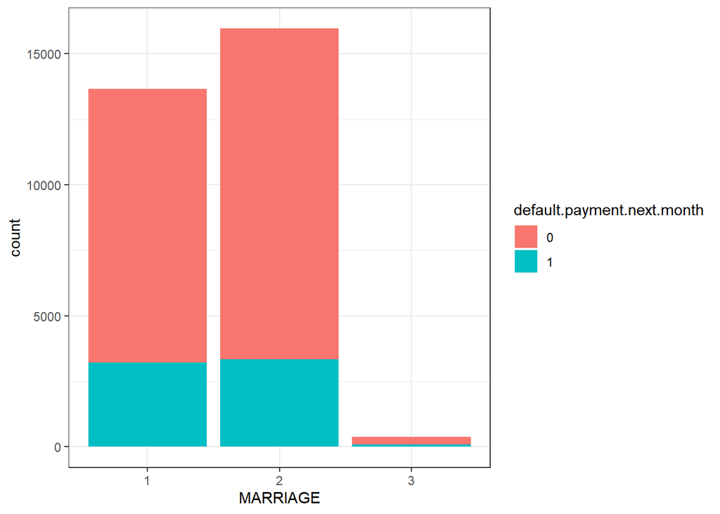

```r
ggplot(credit, aes(x=MARRIAGE,fill=default.payment.next.month))+ geom_bar()+theme_bw()
```

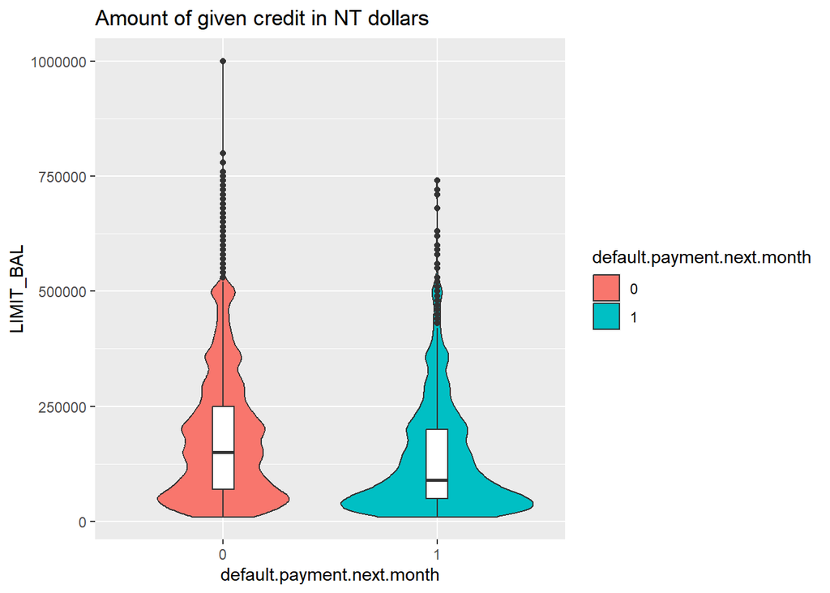

```r
# Default against numeric variables
ggplot(credit, aes(x=default.payment.next.month, y=LIMIT_BAL, fill=default.payment.next.month)) + geom_violin()+
  geom_boxplot(width=0.1, fill="white") + labs(title="Amount of given credit in NT dollars")
```

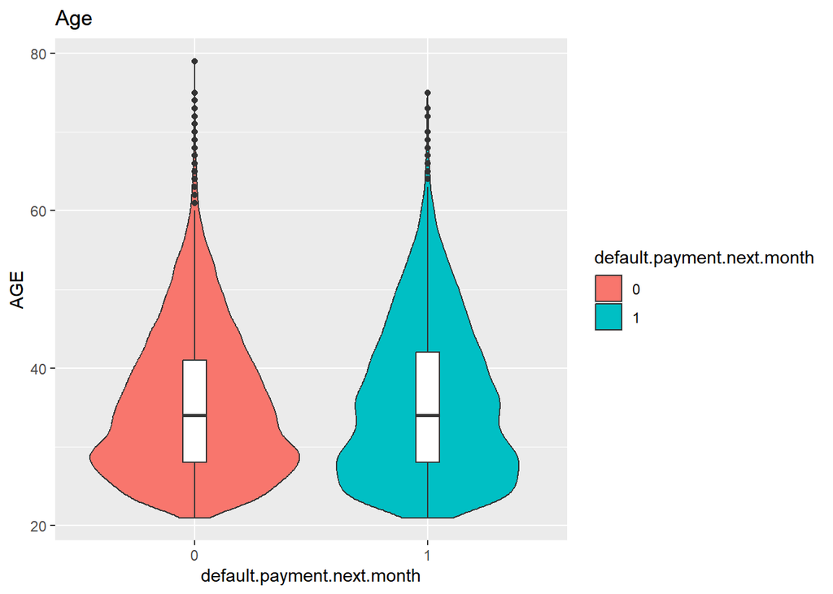

```r
ggplot(credit, aes(x=default.payment.next.month, y=AGE, fill=default.payment.next.month)) + geom_violin()+
  geom_boxplot(width=0.1, fill="white") + labs(title="Age")
```

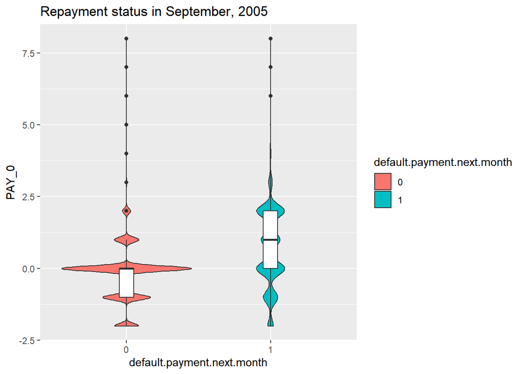

```r
ggplot(credit, aes(x=default.payment.next.month, y=PAY_0, fill=default.payment.next.month)) + geom_violin()+
  geom_boxplot(width=0.1, fill="white") + labs(title="Repayment status in September, 2005")
```

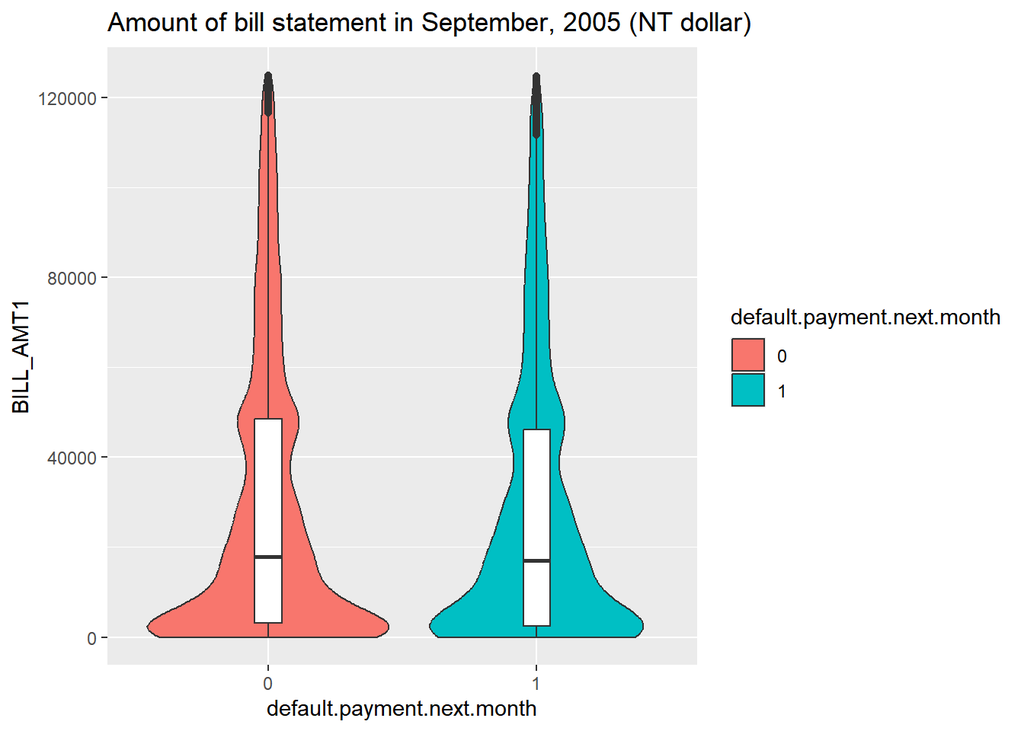

```r
ggplot(credit, aes(x=default.payment.next.month, y=BILL_AMT1, fill=default.payment.next.month)) + geom_violin()+
  geom_boxplot(width=0.1, fill="white") + labs(title="Amount of bill statement in September, 2005 (NT dollar)")+
  ylim(0,125000)
```

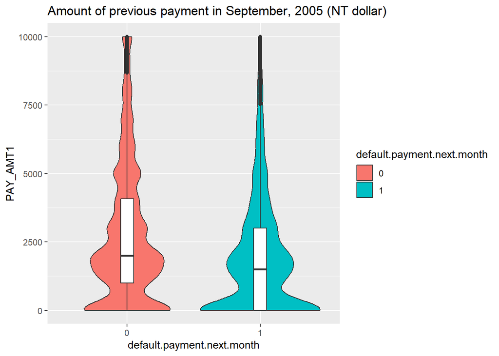

```r
ggplot(credit, aes(x=default.payment.next.month, y=PAY_AMT1, fill=default.payment.next.month)) + geom_violin()+
  geom_boxplot(width=0.1, fill="white") + labs(title="Amount of previous payment in September, 2005 (NT dollar)")+
  ylim(0,10000)
```

### The Logistical Regression

Now that we have conducted all of our data management, and exploratory data analysis. The next part of our project is to conduct a logistical regression. We use a logistical regression because we want to know if the client will 1, default on their payment, or 0, will not default on their payment. With a logistical regression we are able to model what influence the independent variables have on the dependent variable default.payment.next.month if there is an influence then this allows us to predict how likely a client is to default on their next months credit card payment based on their characteristics.

```r
# Logistic model
logit.1 = glm(default.payment.next.month~., data=credit, family="binomial")
summary(logit.1)
```

```
##
## Call:
## glm(formula = default.payment.next.month ~ ., family = "binomial",
##     data = credit)
##
## Coefficients:
##               Estimate Std. Error z value Pr(>|z|)
## (Intercept) -9.945e-01  8.651e-02 -11.495  < 2e-16 ***
## LIMIT_BAL   -7.133e-07  1.577e-07  -4.522 6.11e-06 ***
## SEX2        -1.130e-01  3.073e-02  -3.677 0.000236 ***
## EDUCATION2  -8.452e-02  3.557e-02  -2.376 0.017506 *
## EDUCATION3  -1.130e-01  4.760e-02  -2.375 0.017556 *
## EDUCATION4  -1.162e+00  1.884e-01  -6.169 6.88e-10 ***
## MARRIAGE2   -1.878e-01  3.463e-02  -5.422 5.90e-08 ***
## MARRIAGE3   -1.932e-01  1.319e-01  -1.464 0.143112
## AGE          5.635e-03  1.859e-03   3.031 0.002441 **
## PAY_0        5.775e-01  1.771e-02  32.610  < 2e-16 ***
## PAY_2        8.112e-02  2.020e-02   4.017 5.90e-05 ***
## PAY_3        7.107e-02  2.261e-02   3.143 0.001669 **
## PAY_4        2.289e-02  2.500e-02   0.915 0.359938
## PAY_5        3.418e-02  2.689e-02   1.271 0.203700
## PAY_6        7.179e-03  2.215e-02   0.324 0.745886
## BILL_AMT1   -5.495e-06  1.137e-06  -4.831 1.36e-06 ***
## BILL_AMT2    2.394e-06  1.505e-06   1.591 0.111683
## BILL_AMT3    1.396e-06  1.324e-06   1.054 0.291694
## BILL_AMT4   -1.765e-07  1.352e-06  -0.131 0.896140
## BILL_AMT5    7.716e-07  1.523e-06   0.507 0.612305
## BILL_AMT6    1.770e-07  1.198e-06   0.148 0.882525
## PAY_AMT1    -1.368e-05  2.308e-06  -5.928 3.07e-09 ***
## PAY_AMT2    -9.532e-06  2.089e-06  -4.563 5.03e-06 ***
## PAY_AMT3    -2.622e-06  1.719e-06  -1.525 0.127151
## PAY_AMT4    -4.067e-06  1.786e-06  -2.278 0.022756 *
## PAY_AMT5    -3.142e-06  1.779e-06  -1.766 0.077325 .
## PAY_AMT6    -2.069e-06  1.297e-06  -1.596 0.110534
## ---
## Signif. codes:  0 '***' 0.001 '**' 0.01 '*' 0.05 '.' 0.1 ' ' 1
##
## (Dispersion parameter for binomial family taken to be 1)
##
##     Null deviance: 31705  on 29999  degrees of freedom
## Residual deviance: 27840  on 29973  degrees of freedom
## AIC: 27894
##
## Number of Fisher Scoring iterations: 6
```

### Predicting Credit Default Rates

Using our logistical model logit.1, we will predict the likely hood of a client defaulting on their next months credit card payment.

```r
pred = predict(logit.1, type = "response", credit)
summary(pred)
```

```
##    Min. 1st Qu.  Median    Mean 3rd Qu.    Max.
##  0.0000  0.1177  0.1941  0.2212  0.2587  0.9936
```

### “ROC” Reciver Operating Characteristic and “AUC” Area Under the Curve

Let’s create a visual for the ROC curve with the AUC value displayed. The ROC curve in logistical regression is used for determining the best cutoff value for predicting whether a new observation in this case a client will “default on their payment” (1) or a “not default on their payment” (0). The ideal location for the ROC is in the top left corner which is a high true positive rate and low false positive rate. The AUC is an aggregated metric that evaluates how well a logistic regression model classifies positive and negative outcomes at all possible cutoffs. The closer the value is to 1 the better.

```r
# ROC and AUC-
library(pROC)
glm.roc = roc(response = credit$default.payment.next.month, predictor = pred)
```

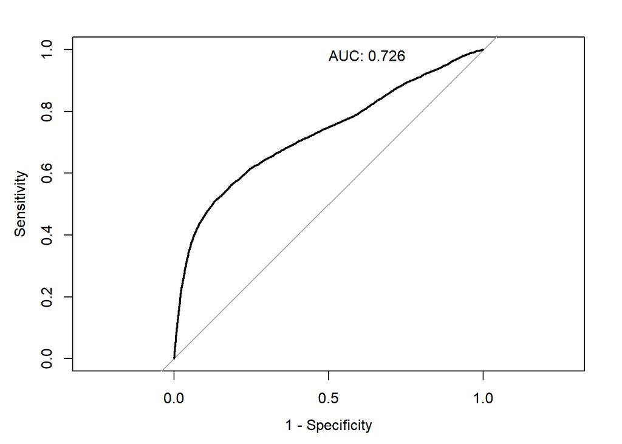

```r
plot(glm.roc, legacy.axes = TRUE, print.auc.y = 1.0, print.auc = TRUE)
```

```r
coords(glm.roc, "best", "threshold")
```

```
##   threshold specificity sensitivity
## 1 0.2753573   0.8685157   0.5096444
```

```r
library(caret)
# Threshold = 0.5
pred_default = factor(ifelse(pred >=0.5, "Yes", "No"))
credit$default.payment.next.month = factor(ifelse(credit$default.payment.next.month==1, "Yes","No"))
confusionMatrix (pred_default, credit$default.payment.next.month, positive = "Yes")
```

```
## Confusion Matrix and Statistics
##
##           Reference
## Prediction    No   Yes
##        No  22729  5034
##        Yes   635  1602
##
##                Accuracy : 0.811
##                  95% CI : (0.8066, 0.8154)
##     No Information Rate : 0.7788
##     P-Value [Acc > NIR] : < 2.2e-16
##
##                   Kappa : 0.2809
##
##  Mcnemar's Test P-Value : < 2.2e-16
##
##             Sensitivity : 0.24141
##             Specificity : 0.97282
##          Pos Pred Value : 0.71614
##          Neg Pred Value : 0.81868
##              Prevalence : 0.22120
##          Detection Rate : 0.05340
##    Detection Prevalence : 0.07457
##       Balanced Accuracy : 0.60712
##
##        'Positive' Class : Yes
##
```

### Searching for a Better Threshold using Two Methods

Next we want to know if the original threshold we selected was the best threshold at .5 or could we have chosen a different cutoff point to get better results? To find a better threshold we will create a chart which plots out the sensitivity, specificity, and accuracy curves for the model above. The value will be on the Y - axis between 0 and 1. On the X - axis will be the possible cut offs between 0 to 1.

### Optimal Cutoff

The optimal Cutoff is at the intersection of the sensitivity and specificity curves.

In our case the threshold we selected was .5 and from reviewing the chart we can see that the optimal cut off is between .2 and .3. We could improve our results by decreasing our cutoff point to one between .2 and .3.

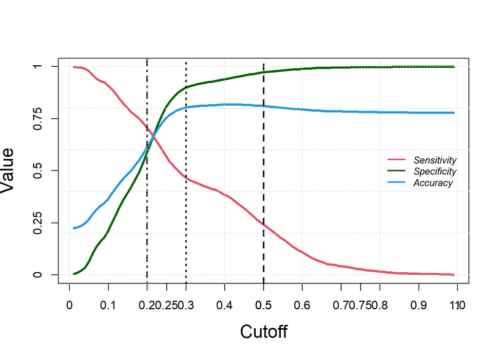

```r
# In search of a better threshold
perform_fn = function(cutoff)
{
  pred_default = factor(ifelse(pred >= cutoff, "Yes", "No"))
  conf <- confusionMatrix(pred_default, credit$default.payment.next.month, positive = "Yes")
  accuray <- conf$overall[1]
  sensitivity <- conf$byClass[1]
  specificity <- conf$byClass[2]
  out <- t(as.matrix(c(sensitivity, specificity, accuray)))
  colnames(out) <- c("sensitivity", "specificity", "accuracy")
  return(out)
}

s = seq(0.01,0.99,length=100)
OUT = matrix(0,100,3)

for(i in 1:100)
{
  OUT[i,] = perform_fn(s[i])
}

plot(s, OUT[,1],xlab="Cutoff",ylab="Value",cex.lab=1.5,cex.axis=1.5,ylim=c(0,1),
     type="l",lwd=3,axes=FALSE,col=2)
axis(1,seq(0,1,length=5),seq(0,1,length=5),cex.lab=1.5)
axis(2,seq(0,1,length=5),seq(0,1,length=5),cex.lab=1.5)
lines(s,OUT[,2],col="darkgreen",lwd=3)
lines(s,OUT[,3],col=4,lwd=3)
box()
legend("right",col=c(2,"darkgreen",4,"darkred"),text.font =3,inset = 0.02,
       box.lty=0,cex = 0.8,
       lwd=c(2,2,2,2),c("Sensitivity","Specificity","Accuracy"))
abline(v = 0.5, col="black", lwd=2, lty=2)
abline(v = 0.3, col="black", lwd=2, lty=3)
abline(v = 0.2, col="black", lwd=2, lty=4)
axis(1, at = seq(0.1, 1, by = 0.1))
grid()
```

### Conducting “PCA” Principal Component Analysis

In this part of our analysis we will conduct a “PCA” or principal component analysis.

```r
## Remove the dependent variable
credit2=credit1[!names(credit1) %in% c("ID","default.payment.next.month")]

# Principal Component Analysis
str(credit2)  # Make sure all variables are numerical
```

```
## 'data.frame':    30000 obs. of  23 variables:
##  $ LIMIT_BAL: num  20000 120000 90000 50000 50000 50000 500000 100000 140000 20000 ...
##  $ SEX      : int  2 2 2 2 1 1 1 2 2 1 ...
##  $ EDUCATION: int  2 2 2 2 2 1 1 2 3 3 ...
##  $ MARRIAGE : int  1 2 2 1 1 2 2 2 1 2 ...
##  $ AGE      : int  24 26 34 37 57 37 29 23 28 35 ...
##  $ PAY_0    : int  2 -1 0 0 -1 0 0 0 0 -2 ...
##  $ PAY_2    : int  2 2 0 0 0 0 0 -1 0 -2 ...
##  $ PAY_3    : int  -1 0 0 0 -1 0 0 -1 2 -2 ...
##  $ PAY_4    : int  -1 0 0 0 0 0 0 0 0 -2 ...
##  $ PAY_5    : int  -2 0 0 0 0 0 0 0 0 -1 ...
##  $ PAY_6    : int  -2 2 0 0 0 0 0 -1 0 -1 ...
##  $ BILL_AMT1: num  3913 2682 29239 46990 8617 ...
##  $ BILL_AMT2: num  3102 1725 14027 48233 5670 ...
##  $ BILL_AMT3: num  689 2682 13559 49291 35835 ...
##  $ BILL_AMT4: num  0 3272 14331 28314 20940 ...
##  $ BILL_AMT5: num  0 3455 14948 28959 19146 ...
##  $ BILL_AMT6: num  0 3261 15549 29547 19131 ...
##  $ PAY_AMT1 : num  0 0 1518 2000 2000 ...
##  $ PAY_AMT2 : num  689 1000 1500 2019 36681 ...
##  $ PAY_AMT3 : num  0 1000 1000 1200 10000 657 38000 0 432 0 ...
##  $ PAY_AMT4 : num  0 1000 1000 1100 9000 ...
##  $ PAY_AMT5 : num  0 0 1000 1069 689 ...
##  $ PAY_AMT6 : num  0 2000 5000 1000 679 ...
```

```r
pr.out=prcomp(credit2, scale=TRUE)
summary(pr.out)
```

```
## Importance of components:
##                           PC1    PC2     PC3     PC4     PC5     PC6     PC7
## Standard deviation     2.5579 2.0244 1.24538 1.21337 1.01254 0.97837 0.95267
## Proportion of Variance 0.2845 0.1782 0.06743 0.06401 0.04458 0.04162 0.03946
## Cumulative Proportion  0.2845 0.4627 0.53010 0.59411 0.63869 0.68031 0.71977
##                            PC8     PC9    PC10    PC11    PC12    PC13   PC14
## Standard deviation     0.94213 0.93341 0.88483 0.85603 0.82633 0.75561 0.7241
## Proportion of Variance 0.03859 0.03788 0.03404 0.03186 0.02969 0.02482 0.0228
## Cumulative Proportion  0.75836 0.79624 0.83028 0.86214 0.89183 0.91665 0.9395
##                           PC15   PC16    PC17   PC18    PC19    PC20    PC21
## Standard deviation     0.63533 0.5098 0.49913 0.4344 0.36302 0.26487 0.20195
## Proportion of Variance 0.01755 0.0113 0.01083 0.0082 0.00573 0.00305 0.00177
## Cumulative Proportion  0.95700 0.9683 0.97913 0.9873 0.99307 0.99612 0.99789
##                          PC22    PC23
## Standard deviation     0.1590 0.15238
## Proportion of Variance 0.0011 0.00101
## Cumulative Proportion  0.9990 1.00000
```

```r
pr.out$rotation[,1:5]
```

```
##                    PC1         PC2         PC3         PC4          PC5
## LIMIT_BAL  0.068518432 -0.31632288  0.01745352 -0.06998363 -0.149540032
## SEX       -0.021656456 -0.03059473  0.02403751  0.07823050  0.884073129
## EDUCATION  0.019205612  0.09152254 -0.31642580 -0.24658459  0.364899185
## MARRIAGE  -0.005600261  0.04325094  0.45318475  0.44456143 -0.053334164
## AGE        0.014231523 -0.06657803 -0.46234666 -0.46275277 -0.163911827
## PAY_0      0.161081970  0.29812388 -0.01750759 -0.01595915 -0.034525055
## PAY_2      0.194119641  0.33482061  0.01777371 -0.04986817 -0.037049923
## PAY_3      0.200213038  0.34389407  0.06173052 -0.08427260 -0.023651708
## PAY_4      0.207038234  0.34458144  0.08892977 -0.10936684 -0.007808684
## PAY_5      0.210960472  0.33160038  0.10870764 -0.11557615  0.001693602
## PAY_6      0.206412352  0.30579387  0.11086652 -0.10989005  0.012287556
## BILL_AMT1  0.334385122 -0.13981517 -0.15087731  0.16795275 -0.013166612
## BILL_AMT2  0.345796995 -0.14022699 -0.12705654  0.14929984  0.004573781
## BILL_AMT3  0.349777117 -0.14621339 -0.08391571  0.10478871  0.029859983
## BILL_AMT4  0.353883216 -0.14544983 -0.07050889  0.10060975  0.022571878
## BILL_AMT5  0.351752413 -0.14376087 -0.05656876  0.08874383  0.022348557
## BILL_AMT6  0.344514390 -0.14187216 -0.04754931  0.08406333  0.010474172
## PAY_AMT1   0.094231230 -0.14910947  0.28186544 -0.28036144  0.092719666
## PAY_AMT2   0.078680876 -0.13987190  0.30183549 -0.31099803  0.107915182
## PAY_AMT3   0.086394185 -0.15157010  0.28030030 -0.27823080  0.036235899
## PAY_AMT4   0.077792717 -0.14140907  0.23738158 -0.23648531  0.013948059
## PAY_AMT5   0.075354430 -0.13719050  0.19426727 -0.17616847 -0.056760335
## PAY_AMT6   0.069948157 -0.12939638  0.20930512 -0.20718627 -0.051711106
```

### K-Means Cluster for Classification

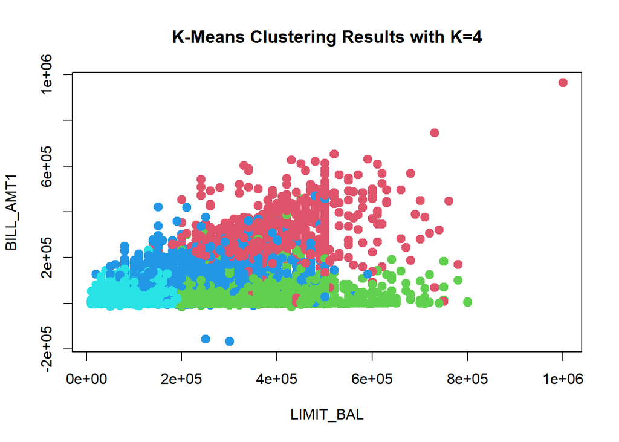

```r
plot(credit2[,c("LIMIT_BAL","BILL_AMT1")], col=(km1$cluster+1),
     main="K-Means Clustering Results with K=4",
     xlab="LIMIT_BAL", ylab="BILL_AMT1", pch=20, cex=2)
```

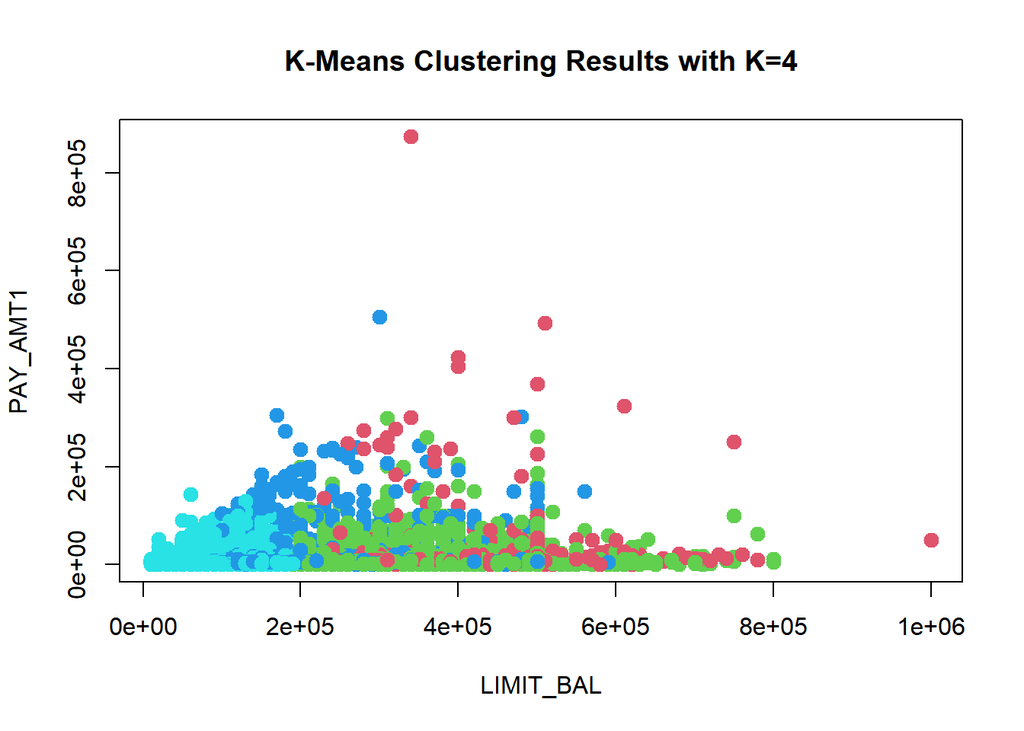

```r
plot(credit2[,c("LIMIT_BAL","PAY_AMT1")], col=(km1$cluster+1),
     main="K-Means Clustering Results with K=4",
     xlab="LIMIT_BAL", ylab="PAY_AMT1", pch=20, cex=2)
```

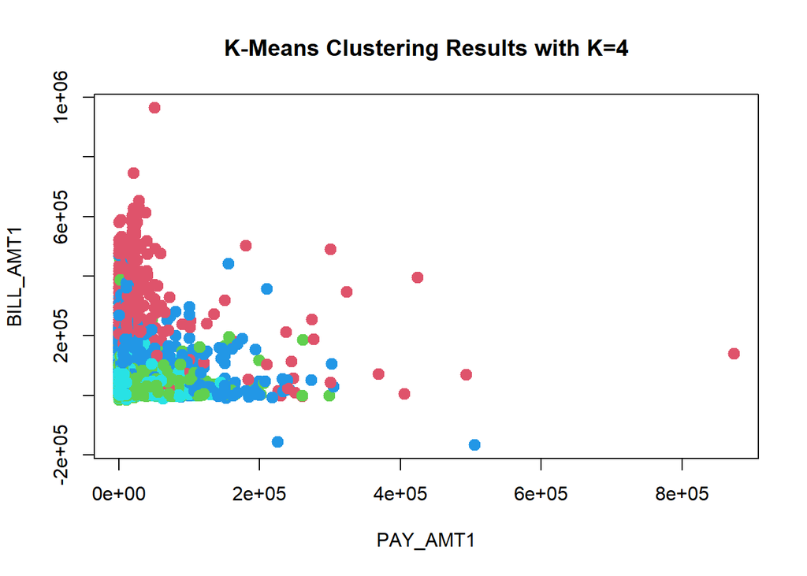

```r
plot(credit2[,c("PAY_AMT1","BILL_AMT1")], col=(km1$cluster+1),
     main="K-Means Clustering Results with K=4",
     xlab="PAY_AMT1", ylab="BILL_AMT1", pch=20, cex=2)
```

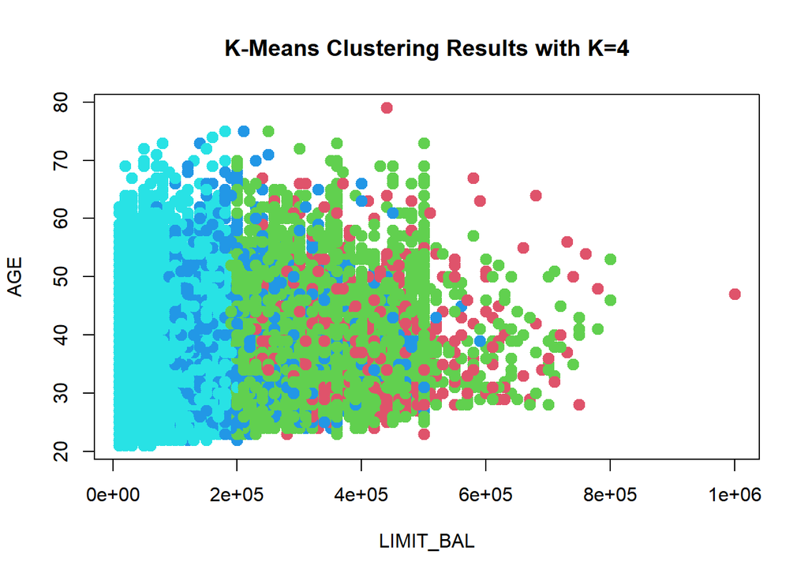

```r
plot(credit2[,c("LIMIT_BAL","AGE")], col=(km1$cluster+1),
     main="K-Means Clustering Results with K=4",
     xlab="LIMIT_BAL", ylab="AGE", pch=20, cex=2)
```

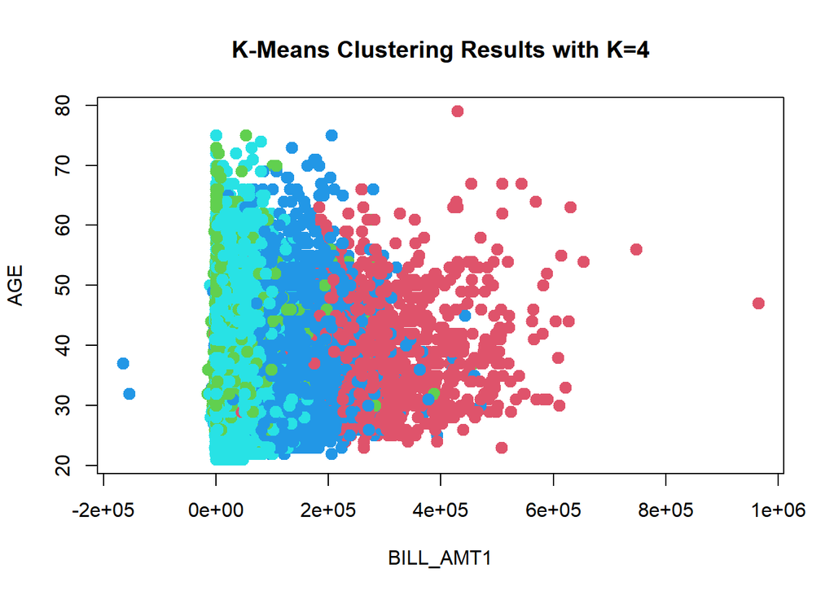

```r
plot(credit2[,c("BILL_AMT1","AGE")], col=(km1$cluster+1),
     main="K-Means Clustering Results with K=4",
     xlab="BILL_AMT1", ylab="AGE", pch=20, cex=2)
```

### Conclusion

The Default of Credit Card Clients data set allowed us to practice key data skills. The first was data acquisition, by obtaining and importing our data into RStudio. The second was data preparation, by cleaning and manipulating the variables within the data set to prepare for the analytics portion of the project. The third was the data analytics phase, using statistics, logistical regression, and predictive models to uncover insights into our dependent and independent variables. the last data skill we practiced was data visualization, by creating charts and graphs throughout the project to better portray what was happening within the data.